# Partial function evaluation in pirouette

This vignette describes partial function evaluation used in `pirouette`.

```r
library(pirouette)
```

We’ll use `pryr` (from the Tidyverse to get that functionality.

```r
library(pryr)
```

## The functions

These are the functions we’ll create, in order of increasing complexity:

1. Create a twin tree
2. Create a true alignment
3. Create a twin alignment

## 1. create a twin tree

We start from a simple true tree:

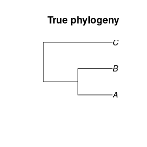

```r
true_phylogeny <- ape::read.tree(text = "((A:1, B:1):1, C:2);")
ape::plot.phylo(true_phylogeny, main = "True phylogeny")
```

To create a twin tree, I will describe:

- 1.1 Create a twin tree using the defaults
- 1.2 Create a twin tree using a built-in BD model
- 1.3 Create a twin tree using a custom function
- 1.4 Create a twin tree using a custom function with more arguments
- 1.5 Create a twin tree using a built-in function with more arguments that uses the Yule speciation model
- 1.6 Create a twin tree using a built-in function to copy a tree

### 1.1 Create a twin tree using the defaults

To create a twin tree from the true tree using the default settings is easily done by calling `create_twin_tree`:

```r
twin_tree <- pirouette::create_twin_tree(true_phylogeny)
ape::plot.phylo(twin_tree, main = "Twin phylogeny")
```

The `create_twin_tree` function creates the twin tree in the way specified in its other function argument: the `twinning_params`:

```r
twinning_params <- pirouette::create_twinning_params()
```

Calling `create_twin_tree` results in the same twin tree (yes, go ahead and check!):

```r
twin_tree <- pirouette::create_twin_tree(
  phylogeny = true_phylogeny,
  twinning_params = twinning_params
)
ape::plot.phylo(twin_tree, main = "Twin phylogeny")
```

## 1.2 Create a twin tree using a built-in BD model

How to specify *how* the twin tree is created? Set the value for the `twinning_params$sim_twin_tree_fun`!

I’ll demonstrate using the `get_sim_bd_twin_tree_fun` which produces a function that simulates a twin tree using a Birth-Death speciation model:

```r
twinning_params <- pirouette::create_twinning_params(
  sim_twin_tree_fun = pirouette::get_sim_bd_twin_tree_fun()
)
```

Proceed as usual here to simulate the twin tree:

```r
twin_tree <- pirouette::create_twin_tree(
  phylogeny = true_phylogeny,
  twinning_params = twinning_params
)
ape::plot.phylo(twin_tree, main = "Twin phylogeny")
```

### 1.3 Create a twin tree using a custom function

`twinning_params$sim_twin_tree_fun` must be a function that takes *one* argument, which must be the true phylogeny.

Here is an example that creates a twin tree by simulation a random coalescent tree with the same number of tips:

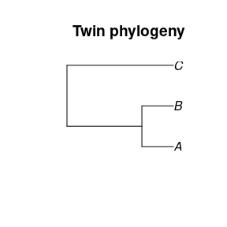

```r
# Define my function
my_fun <- function(true_phylogeny) {
  new_phylo <- ape::rcoal(n = ape::Ntip(true_phylogeny))
  new_phylo$tip.label <- true_phylogeny$tip.label # nolint ape style, not mine
  new_phylo
}
# Put my function in the twinning_params
twinning_params <- pirouette::create_twinning_params(
  sim_twin_tree_fun = my_fun
)
# Create a twin tree using my function
twin_tree <- pirouette::create_twin_tree(
  phylogeny = true_phylogeny,
  twinning_params = twinning_params
)
# Show the twin tree created by my function
ape::plot.phylo(twin_tree, main = "Twin phylogeny")
```

### 1.4 Create a twin tree using a built-in function with more arguments

So, `twinning_params$sim_twin_tree_fun` must be a function that takes *one* argument, which is the true phylogeny. What if we want a function that indeed has one argument for the true phylogeny, but also some additional ones?

An example is `sim_bd_twin_tree`, which uses a method and a number of replicates:

```r
head(sim_bd_twin_tree)
```

```
##
## 1 function (true_phylogeny, method = "random_tree", n_replicates = 10000,
## 2     os = rappdirs::app_dir()$os)
## 3 {
## 4     beastier::check_os(os)
## 5     methods <- c("random_tree", "max_clade_cred", "max_likelihood")
## 6     if (!method %in% methods) {
```

We cannot simply plug it in:

```r
tryCatch(
  pirouette::create_twinning_params(
    sim_twin_tree_fun = sim_bd_twin_tree
  ),
  error = function(e) {
    cat(e$message)
  }
)
```

```
## 'sim_twin_tree_fun' must be a function with one argument
```

Instead, we’ll need partial function evaluation, which will create a function with one a ellipsis (`...`) argument that will fill in the values you specified:

```r
# Create my partially evaluated function
sim_twin_tree_fun <- pryr::partial(
  sim_bd_twin_tree,
  method = "random_tree",
  n_replicates = 1
)
# Create twinning_params with my function
twinning_params <- pirouette::create_twinning_params(
  sim_twin_tree_fun = sim_twin_tree_fun
)
# Create a twin tree using my function
twin_tree <- pirouette::create_twin_tree(
  phylogeny = true_phylogeny,
  twinning_params = twinning_params
)
# Show the twin tree
ape::plot.phylo(twin_tree, main = "Twin phylogeny")
```

There is a helper function called `get_sim_bd_twin_tree_fun` that does the same partial function evaluation for you:

```r
# Create twinning_params with my function
twinning_params <- pirouette::create_twinning_params(
  sim_twin_tree_fun = pirouette::get_sim_bd_twin_tree_fun(
    method = "random_tree",
    n_replicates = 1
  )
)
# Create a twin tree using my function
twin_tree <- pirouette::create_twin_tree(
  phylogeny = true_phylogeny,
  twinning_params = twinning_params
)
# Show the twin tree
ape::plot.phylo(twin_tree, main = "Twin phylogeny")
```

### 1.5 Create a twin tree using a built-in function with more arguments that uses the Yule speciation model

Now using a Yule model:

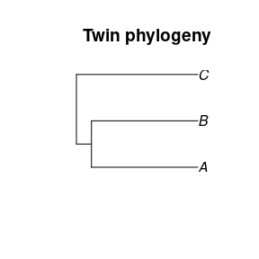

```r
# Create twinning_params with my function
twinning_params <- pirouette::create_twinning_params(
  sim_twin_tree_fun = pirouette::create_sim_yule_twin_tree_fun(
    method = "random_tree",
    n_replicates = 1
  )
)
# Create a twin tree using my function
twin_tree <- create_twin_tree(
  phylogeny = true_phylogeny,
  twinning_params = twinning_params
)
# Show the twin tree
ape::plot.phylo(twin_tree, main = "Twin phylogeny")
```

### 1.6 Create a twin tree using a built-in function to copy a tree

Now using a copy function:

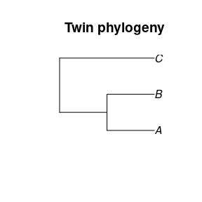

```r
# Create twinning_params
twinning_params <- pirouette::create_twinning_params(
  sim_twin_tree_fun = pirouette::create_copy_twtr_from_true_fun()
)
# Create a twin tree using my function
twin_tree <- create_twin_tree(
  phylogeny = true_phylogeny,
  twinning_params = twinning_params
)
# Show the twin tree
ape::plot.phylo(twin_tree, main = "Twin phylogeny")
```

Using partial function evaluation you can now plug in any function to create a twin tree!

## 2. create a true alignment

We start from a simple true tree:

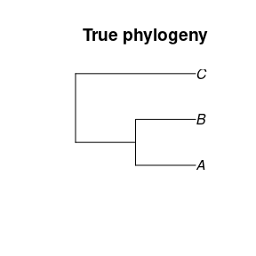

```r
true_phylogeny <- ape::read.tree(text = "((A:1, B:1):1, C:2);")
ape::plot.phylo(true_phylogeny, main = "True phylogeny")
```

Also, we’ll specify a root sequence:

```r
root_sequence <- pirouette::create_blocked_dna(length = 16)
```

We want to create a true alignment from it. There is a function that does so:

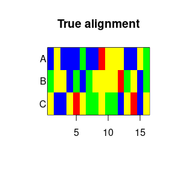

```r
alignment_params <- pirouette::create_alignment_params(
  root_sequence = root_sequence
)
true_alignment <- pirouette::sim_true_alignment(
  true_phylogeny = true_phylogeny,
  alignment_params = alignment_params
)
ape::image.DNAbin(true_alignment, main = "True alignment", legend = FALSE)
```

How to specify *how* the true alignment is created? Use the `alignment_params$sim_tral_fun`:

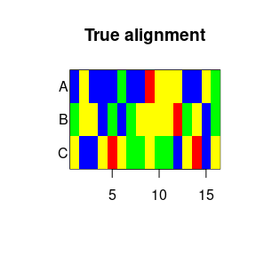

```r
alignment_params <- pirouette::create_alignment_params(
  sim_tral_fun = sim_tral_with_std_nsm,
  root_sequence = root_sequence
)
true_alignment <- pirouette::sim_true_alignment(
  true_phylogeny = true_phylogeny,
  alignment_params = alignment_params
)
ape::image.DNAbin(true_alignment, main = "True alignment", legend = FALSE)
```

Here is an example that creates a true alignment by simulating a random alignment with the same number of taxa:

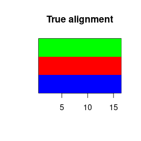

```r
# My function
my_fun <- function(
  true_phylogeny,
  root_sequence
) {
  sequences <- list()
  for (i in seq_len(ape::Ntip(true_phylogeny))) {
    sequences[[i]] <- rep(
      sample(c("a", "c", "g", "t"), size = 1),
      nchar(root_sequence)
    )
  }
  ape::as.DNAbin(sequences)
}
# Putting my function in the alignment_params
alignment_params <- pirouette::create_alignment_params(
  sim_tral_fun = my_fun,
  root_sequence = root_sequence
)
# Simulate the true alignment using my function
true_alignment <- pirouette::sim_true_alignment(
  true_phylogeny = true_phylogeny,
  alignment_params = alignment_params
)
# Show the true alignment
ape::image.DNAbin(true_alignment, main = "True alignment", legend = FALSE)
```

```r
head(sim_tral_with_std_nsm)
```

```
##
## 1 function (true_phylogeny, root_sequence, mutation_rate = 1, site_model = beautier::create_jc69_site_model())
## 2 {
## 3     alignment <- pirouette::sim_alignment_with_std_nsm(phylogeny = true_phylogeny,
## 4         root_sequence = root_sequence, mutation_rate = mutation_rate,
## 5         site_model = site_model)
## 6     pirouette::check_alignment(alignment)
```

To change the default arguments, we’ll need partial function evaluation, which will create a function with one a ellipsis (`...`) argument that will fill in the values you specified:

```r
sim_tral_fun <- pryr::partial(
  sim_tral_with_std_nsm,
  mutation_rate = 0.5,
  site_model = beautier::create_hky_site_model()
)
head(sim_tral_fun)
```

```
##
## 1 function (...)
## 2 sim_tral_with_std_nsm(mutation_rate = 0.5, site_model = beautier::create_hky_site_model(),
## 3     ...)
```

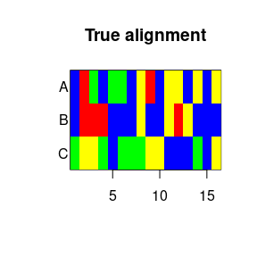

```r
alignment_params <- pirouette::create_alignment_params(
  sim_tral_fun = sim_tral_fun,
  root_sequence = root_sequence
)
true_alignment <- pirouette::sim_true_alignment(
  true_phylogeny = true_phylogeny,
  alignment_params = alignment_params
)
ape::image.DNAbin(true_alignment, main = "True alignment", legend = FALSE)
```

Instead of doing the partial function evaluation yourself, `pirouette` supplies this function as `get_sim_tral_with_std_nsm_fun`:

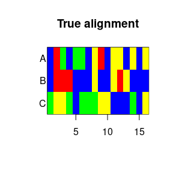

```r
alignment_params <- pirouette::create_alignment_params(
  sim_tral_fun =
    pirouette::get_sim_tral_with_std_nsm_fun(
    mutation_rate = 0.5,
    site_model = beautier::create_hky_site_model()
  ),
  root_sequence = root_sequence
)
true_alignment <- pirouette::sim_true_alignment(
  true_phylogeny = true_phylogeny,
  alignment_params = alignment_params
)
ape::image.DNAbin(true_alignment, main = "True alignment", legend = FALSE)
```

Or to use the linked node substitution model, use `get_sim_tral_with_lns_nsm_fun`:

```r
if (1 == 2) { # nodeSub is not yet on CRAN
  alignment_params <- pirouette::create_alignment_params(
    sim_tral_fun =
      get_sim_tral_with_lns_nsm_fun(
      branch_mutation_rate = 0.1,
      node_mutation_rate = 0.2
    ),
    root_sequence = root_sequence
  )
  true_alignment <- pirouette::sim_true_alignment(
    true_phylogeny = true_phylogeny,
    alignment_params = alignment_params
  )
  ape::image.DNAbin(true_alignment, main = "True alignment", legend = FALSE)
}
```

Or to use the unlinked node substitution model, use `get_sim_tral_with_uns_nsm_fun`:

```r
if (1 == 2) { # nodeSub is not yet on CRAN
  alignment_params <- pirouette::create_alignment_params(
    sim_tral_fun =
      pirouette::get_sim_tral_with_uns_nsm_fun(
        branch_mutation_rate = 1.0,
        node_mutation_rate = 2.0,
        node_time = 0.1
      ),
    root_sequence = root_sequence
  )
  true_alignment <- pirouette::sim_true_alignment(
    true_phylogeny = true_phylogeny,
    alignment_params = alignment_params
  )
  ape::image.DNAbin(true_alignment, main = "True alignment", legend = FALSE)
}
```

Using partial function evaluation you can now plug in any function to create a true alignment.

## 3. create a twin alignment

To create a twin alignment, we need * a twin tree * a true alignent * a root sequence

Note that some of these three elements may be ignored, but is some cases you will need all three.

As the twin tree, we’ll use this:

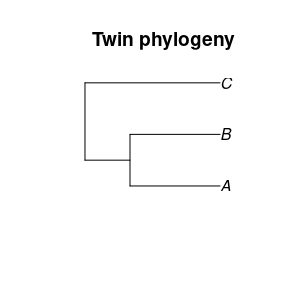

```r
twin_phylogeny <- ape::read.tree(text = "((A:2, B:2):1, C:3);")
ape::plot.phylo(twin_phylogeny, main = "Twin phylogeny")
```

The root sequence is short and simple:

```r
root_sequence <- pirouette::create_blocked_dna(length = 20)
```

As a true alignment, we’ll use something equally simple:

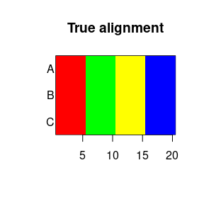

```r
true_alignment <- pirouette::get_test_alignment(
  n_taxa = ape::Ntip(true_phylogeny),
  sequence_length = nchar(root_sequence)
)
ape::image.DNAbin(true_alignment, main = "True alignment", legend = FALSE)
```

I will show multiple ways to create a twin alignment here:

- 3.1. Copy the true alignment
- 3.2. Simulate an alignment based on the twin tree
- 3.3. Simulate an alignment based on the twin tree, true alignment and root sequence

## 3.1. Copy the true alignment

The function we’ll use has three parameters and ignores two:

```r
my_fun <- function(
  twin_phylogeny = "irrelevant",
  true_alignment,
  root_sequence = "irrelevant"
) {
  true_alignment
}
```

Put this function in the `twinning_params`:

```r
twinning_params <- pirouette::create_twinning_params(
  sim_twal_fun = my_fun
)
```

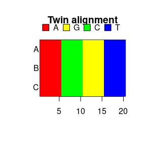

```r
twin_alignment <- pirouette::sim_twin_alignment(
  twin_phylogeny = twin_phylogeny,
  true_alignment = true_alignment,
  alignment_params = pirouette::create_test_alignment_params(
    root_sequence = root_sequence
  ),
  twinning_params = twinning_params
)
ape::image.DNAbin(twin_alignment, main = "Twin alignment")
```

## 3.2. Simulate an alignment based on the twin tree

Now we want to plug in:

```r
head(sim_twal_with_std_nsm)
```

```
##
## 1 function (twin_phylogeny, root_sequence, true_alignment = "irrelevant",
## 2     mutation_rate = 1, site_model = beautier::create_jc69_site_model())
## 3 {
## 4     alignment <- pirouette::sim_alignment_with_std_nsm(phylogeny = twin_phylogeny,
## 5         root_sequence = root_sequence, mutation_rate = mutation_rate,
## 6         site_model = site_model)
```

Here comes partial function evaluation to the rescue:

```r
sim_twin_align_fun <- pryr::partial(
  sim_twal_with_std_nsm,
  mutation_rate = 0.1
)
head(sim_twin_align_fun)
```

```
##
## 1 function (...)
## 2 sim_twal_with_std_nsm(mutation_rate = 0.1, ...)
```

```r
pirouette::check_sim_twal_fun(sim_twin_align_fun)
```

Plugging it in:

```r
twin_alignment <- pirouette::sim_twin_alignment(
  twin_phylogeny = twin_phylogeny,
  true_alignment = true_alignment,
  alignment_params = pirouette::create_test_alignment_params(),
  twinning_params = pirouette::create_twinning_params(
    sim_twal_fun = sim_twin_align_fun
  )
)
ape::image.DNAbin(twin_alignment, main = "Twin alignment", legend = FALSE)
```

Or use `get_sim_twal_with_std_nsm_fun` to do the partial function evaluation for you:

```r
twin_alignment <- pirouette::sim_twin_alignment(
  twin_phylogeny = twin_phylogeny,
  true_alignment = true_alignment,
  alignment_params = pirouette::create_test_alignment_params(),
  twinning_params = pirouette::create_twinning_params(
    sim_twal_fun =
      pirouette::get_sim_twal_with_std_nsm_fun(
        mutation_rate = 0.1
      )
  )
)
ape::image.DNAbin(twin_alignment, main = "Twin alignment", legend = FALSE)
```

## 3.3. Simulate an alignment based on the twin tree, true alignment and root sequence

Now we want to plug in:

```r
head(sim_twal_with_same_n_mutation)
```

```
##
## 1 function (twin_phylogeny, true_alignment, root_sequence, mutation_rate = 1,
## 2     site_model = beautier::create_jc69_site_model(), max_n_tries = 1000,
## 3     verbose = FALSE)
## 4 {
## 5     beautier::check_phylogeny(twin_phylogeny)
## 6     pirouette::check_alignment(true_alignment)
```

Here comes partial function evaluation to the rescue:

```r
sim_twin_align_fun <- pryr::partial(
  sim_twal_with_same_n_mutation,
  mutation_rate = 0.5
)
head(sim_twin_align_fun)
```

```
##
## 1 function (...)
## 2 sim_twal_with_same_n_mutation(mutation_rate = 0.5, ...)
```

```r
pirouette::check_sim_twal_fun(sim_twin_align_fun)
```

Plugging it in:

```r
twin_alignment <- pirouette::sim_twin_alignment(
  twin_phylogeny = twin_phylogeny,
  true_alignment = true_alignment,
  alignment_params = pirouette::create_test_alignment_params(
    root_sequence = root_sequence
  ),
  twinning_params = pirouette::create_twinning_params(
    sim_twal_fun = sim_twin_align_fun
  )
)
```

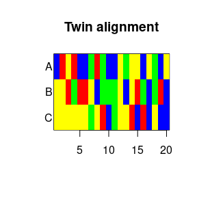

```r
ape::image.DNAbin(twin_alignment, main = "Twin alignment", legend = FALSE)
```

Or use `get_sim_twal_with_std_nsm_fun` to do the partial function evaluation for you:

```r
twin_alignment <- pirouette::sim_twin_alignment(
  twin_phylogeny = twin_phylogeny,
  true_alignment = true_alignment,
  alignment_params = pirouette::create_test_alignment_params(),
  twinning_params = pirouette::create_twinning_params(
    sim_twal_fun =
      pirouette::get_sim_twal_with_std_nsm_fun(
        mutation_rate = 0.1
      )
  )
)
ape::image.DNAbin(twin_alignment, main = "Twin alignment", legend = FALSE)
```